# decomp

Author

Aryan Safi and Kelli Marquardt

Published

March 23, 2026

## Inflation

Inflation is typically measured as the percentage change in a price index over time. A price index (CPI or PCEPI) is a weighted average of prices:

$$P_t = \sum_i w_i \times p_{i,t}$$

| Object | Definition |
| --- | --- |
| $w_i$ | weight for item/service $i$ |
| $p_{i,t}$ | the price of item/service $i$ at $t$ |

**Inflation** is then:

$$\pi_t = \frac{P_t - P_{t-k}}{P_{t-k}}$$

and $k$ is typically 12 indicating the year over year inflation in prices provided monthly.

## Decomposition into weights and prices

To decompose inflation into (i) prices and (ii) weights, we have two options:

### Laspeyres-style (base period weights)

$$\Delta P_t^L = \underbrace{\sum_i w_{i,t-k} \times \Delta p_i}_{\text{Price Component}} + \underbrace{\sum_i \Delta w_i \times p_{i, t}}_{\text{Weight Component}}$$

### Paasche-style (current period weights)

$$\Delta P_{t-k,t}^P = \underbrace{\sum_i w_{i,t} \times \Delta p_i}_{\text{Price Component}} + \underbrace{\sum_i \Delta w_i \times p_{i, t-k}}_{\text{Weight Component}}$$

| Term | Definition |
| --- | --- |
| $\Delta p_i$ | $p_{i,t} - p_{i, t-k}$ |
| $\Delta w_i$ | $w_{i,t} - w_{i, t-k}$ |

## Walkthrough Example

### The Data

Suppose we have the following healthcare sector with just two services: Medicare and Private

| Type | Period 0 | Period 1 |
| --- | --- | --- |
| Medicare Price | 10 | 12 |
| Private Price | 5 | 8 |
| Medicare Weight | 0.7 | 0.6 |
| Private Weight | 0.3 | 0.4 |

Notice that both prices rose, but the weights shifted toward private insurance.

### Laspeyres Decomposition

$$\underbrace{0.7 * (12-10)}_{\text{Medicare}} + \underbrace{0.3 * (8-5)}_{\text{Private}} = 2.3
\tag{Price Component}$$

$$\underbrace{12 * (0.6-0.7)}_{\text{Medicare}} + \underbrace{8 * (0.4-0.3)}_{\text{Private}} = -0.4
\tag{Weight Component}$$

$$2.3 + -0.4 = \boxed{1.9}
\tag{Total Change}$$

We can verify this is true by computing inflation directly. We compute the price index in each period and then calculate the difference.

$$P_0 = 0.7 * 10 + 0.3*5 = 8.5$$

$$P_1 = 0.6 * 12 + 0.4 * 8 = 10.4$$

$$\Delta P_{0,1} = 10.4 - 8.5 = \boxed{1.9}$$

Verified!

### Paasche Decomposition

$$\underbrace{0.6 * (12-10)}_{\text{Medicare}} + \underbrace{0.4 * (8-5)}_{\text{Private}} = 2.4
\tag{Price Component}$$

$$\underbrace{10 * (0.6-0.7)}_{\text{Medicare}} + \underbrace{5 * (0.4-0.3)}_{\text{Private}} = -0.5
\tag{Weight Component}$$

$$2.4 + (-0.5) = \boxed{1.9}
\tag{Total Change}$$

Same change!

### Summary

|  | Laspeyres-style | Paasche-style | Interpretation |
| --- | --- | --- | --- |
| Price Component | +2.3 | +2.4 | If consumers had kept their baskets fixed each period, the index would have risen by this much |
| Weight Component | -0.4 | -0.5 | Consumers shifted toward Private insurance. This is the “substitution” effect. This partially offset price increases. |
| **Total** | +1.9 | +1.9 | Total change in the price index between $t-k$ and $t$ |

### Key Conceptual Differences

| Type | Laspeyres | Paasche |
| --- | --- | --- |
| Price effect evaluated at | Old weights | New weights |
| Weight effect evaluated at | New prices | Old prices |
| Emphasizes | What inflation *would have been* without behavioral change | What inflation *was experienced* given consumption behavior |

For our project, Laspeyres is useful if we’re trying to answer: “How much did hospital input cost rise, holding service mix constant?” - isolating pure cost pressures. Paasche might be useful if we’re asking “Given how hospitals changed their mix, what drove observed spending growth?” - capturing the realized experience.

### By-Payer Decomposition

Note, we can also take the work we have done to aggregate by **payer type**. Recall the two expressions we created for the **Laspeyres** Decomposition as an example.

**Note**

**Recall**
$$\underbrace{0.7 * (12-10)}_{\text{Medicare}} + \underbrace{0.3 * (8-5)}_{\text{Private}} = 2.3
\tag{Price Component}$$

$$\underbrace{12 * (0.6-0.7)}_{\text{Medicare}} + \underbrace{8 * (0.4-0.3)}_{\text{Private}} = -0.4
\tag{Weight Component}$$

$$\underbrace{0.7 * (12-10)}_{\text{Medicare Price}} + \underbrace{12 * (0.6-0.7)}_{\text{Medicare Weight}} = 0.2
\tag{Medicare Component}$$

$$\underbrace{0.3 * (8-5)}_{\text{Private Price}} + \underbrace{8 * (0.4-0.3)}_{\text{Private Weight}} = 1.7
\tag{Private Component}$$

And finally, we can verify that these also sum to the total inflation.

$$1.7 + 0.2 = \boxed{1.9}$$

## Industry-Based PPI

### Producer Price Index (Monthly)

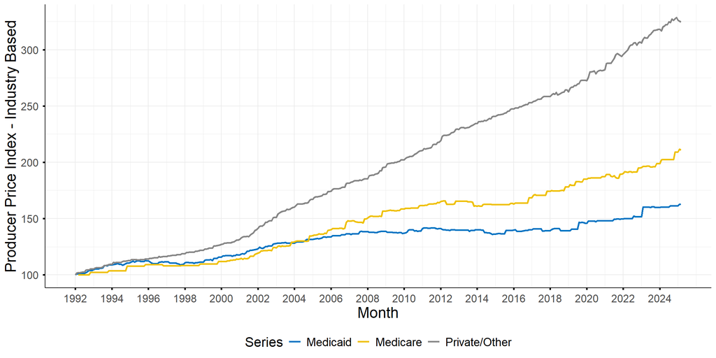

```r
# read haver ppi
ppi = import_haver(series = c("R62211A2@PPIR",
                              "R62211A4@PPIR",
                              "R62211A6@PPIR"),eop = F) |>
  rename(ppi_Medicare = r62211a2,
         ppi_Medicaid = r62211a4,
         ppi_Other = r62211a6)


ppi |>
  pivot_longer(cols = !date,
               names_to = 'Series',
               values_to = 'Value') |>
  mutate(Series = str_replace_all(Series, 'ppi_', '')) |>
  mutate(Series = ifelse(Series == 'Other', 'Private/Other', Series)) |>
  ggplot(aes(x = date, color = Series, y = Value)) +
  # geom_point() +
  geom_line(linewidth = 1.05) +
  labs(y = 'Producer Price Index - Industry Based', x = 'Month') +
  scale_color_manual(values = ggpubr::get_palette('jco', 3)) +
  scale_x_date(breaks = seq.Date(min(ppi$date), max(ppi$date), by = "2 years"),
               date_labels = "%Y")
```

```r
DT::datatable(ppi, caption = 'Producer Price Index (Haver)',
              rownames = F,
              extensions = 'Buttons',
              options = list(
                dom = 'Bfrtip',
                buttons = c('copy', 'csv', 'excel')
              ))
```

| date | ppi_Medicare | ppi_Medicaid | ppi_Other |
| --- | --- | --- | --- |
| 1992-12-01 | 100 | 100 | 100 |
| 1993-01-01 |  | 100.9 | 101.6 |
| 1993-02-01 | 100 | 100.9 | 102 |
| 1993-03-01 | 100 | 101 | 102.1 |
| 1993-04-01 | 100 | 101 | 102.3 |
| 1993-05-01 | 100 | 101.3 | 102.5 |
| 1993-06-01 | 100 | 101.3 | 102.6 |
| 1993-07-01 | 100 | 102.1 | 104.2 |
| 1993-08-01 | 100 | 102.8 | 104.6 |
| 1993-09-01 | 100 | 104 | 104.6 |

[output cut: 389 more lines]

### Producer Price Index (Annual)

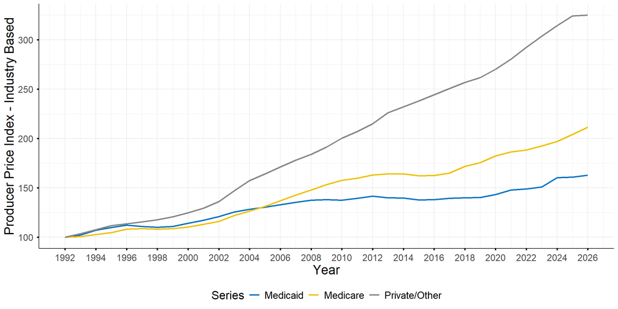

```r
# store ppi yearly by taking average
ppi_yearly = ppi |>
  mutate(
    year = year(date)
  ) |>
  group_by(year) |>
  summarise(
    ppi_Medicare = mean(ppi_Medicare, na.rm = T),
    ppi_Medicaid = mean(ppi_Medicaid, na.rm = T),
    ppi_Other = mean(ppi_Other, na.rm = T)
  )|>
  ungroup()

ppi_yearly |>
  pivot_longer(
    cols = !year,
    names_to = 'Series',
    values_to = 'Value'
  ) |>
  mutate(Series = str_replace_all(Series, 'ppi_', '')) |>
  mutate(Series = ifelse(Series == 'Other', 'Private/Other', Series)) |>
  ggplot(aes(x = year, color = Series, y = Value)) +
  # geom_point() +
  geom_line(linewidth = 1.05) +
  labs(
    y = 'Producer Price Index - Industry Based',
    x = 'Year'
  ) +
  scale_color_manual(values = ggpubr::get_palette('jco', 3)) +
  scale_x_continuous(breaks = seq(min(ppi_yearly$year), max(ppi_yearly$year), by = 2))
```

### Producer Price Index % YoY Changes (Monthly)

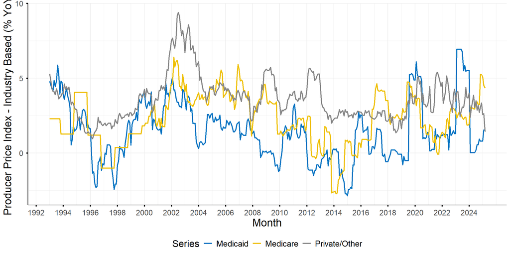

```r
ppi |>
  mutate(
    ppi_Medicare = 100 * (ppi_Medicare - lag(ppi_Medicare, 12)) / lag(ppi_Medicare, 12),
    ppi_Medicaid = 100 * (ppi_Medicaid - lag(ppi_Medicaid, 12)) / lag(ppi_Medicaid, 12),
    ppi_Other = 100 * (ppi_Other - lag(ppi_Other, 12)) / lag(ppi_Other, 12)
    ) |>
  na.omit() |>
  pivot_longer(cols = !date,
               names_to = 'Series',
               values_to = 'Value') |>
  mutate(Series = str_replace_all(Series, 'ppi_', '')) |>
  mutate(Series = ifelse(Series == 'Other', 'Private/Other', Series)) |>
  ggplot(aes(x = date, color = Series, y = Value)) +
  # geom_point() +
  geom_line(linewidth = 1.05) +
  labs(y = 'Producer Price Index - Industry Based (% YoY)', x = 'Month') +
  scale_color_manual(values = ggpubr::get_palette('jco', 3)) +
  scale_x_date(breaks = seq.Date(min(ppi$date), max(ppi$date), by = "2 years"),
               date_labels = "%Y")
```

```r
DT::datatable(ppi, caption = 'Producer Price Index (Haver)',
              rownames = F,
              extensions = 'Buttons',
              options = list(
                dom = 'Bfrtip',
                buttons = c('copy', 'csv', 'excel')
              ))
```

| date | ppi_Medicare | ppi_Medicaid | ppi_Other |
| --- | --- | --- | --- |
| 1992-12-01 | 100 | 100 | 100 |
| 1993-01-01 |  | 100.9 | 101.6 |
| 1993-02-01 | 100 | 100.9 | 102 |
| 1993-03-01 | 100 | 101 | 102.1 |
| 1993-04-01 | 100 | 101 | 102.3 |
| 1993-05-01 | 100 | 101.3 | 102.5 |
| 1993-06-01 | 100 | 101.3 | 102.6 |
| 1993-07-01 | 100 | 102.1 | 104.2 |
| 1993-08-01 | 100 | 102.8 | 104.6 |
| 1993-09-01 | 100 | 104 | 104.6 |

[output cut: 389 more lines]

### Producer Price Index % YoY Change (Annual)

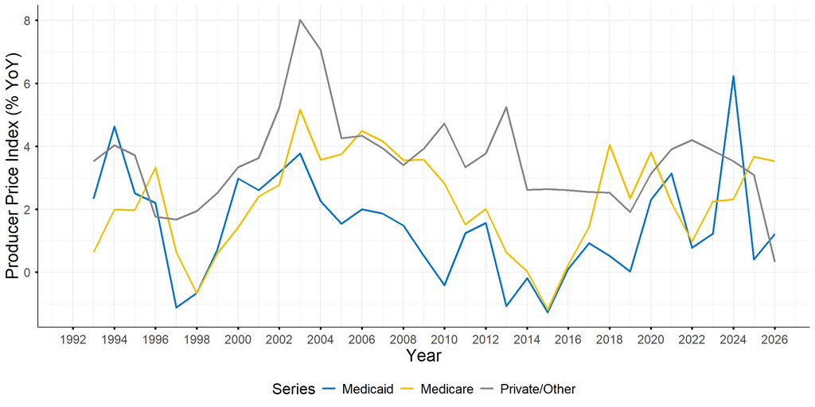

```r
# store ppi yearly by taking average
ppi_yearly |>
  mutate(
    ppi_Medicare = 100 * (ppi_Medicare - lag(ppi_Medicare, 1)) / lag(ppi_Medicare, 1),
    ppi_Medicaid = 100 * (ppi_Medicaid - lag(ppi_Medicaid, 1)) / lag(ppi_Medicaid, 1),
    ppi_Other = 100 * (ppi_Other - lag(ppi_Other, 1)) / lag(ppi_Other, 1)
  ) |>
  pivot_longer(
    cols = !year,
    names_to = 'Series',
    values_to = 'Value'
  ) |>
  mutate(Series = str_replace_all(Series, 'ppi_', '')) |>
  mutate(Series = ifelse(Series == 'Other', 'Private/Other', Series)) |>
  ggplot(aes(x = year, color = Series, y = Value)) +
  # geom_point() +
  geom_line(linewidth = 1.05) +
  labs(
    y = 'Producer Price Index (% YoY)',
    x = 'Year'
  ) +
  scale_color_manual(values = ggpubr::get_palette('jco', 3)) +
  scale_x_continuous(breaks = seq(min(ppi_yearly$year), max(ppi_yearly$year), by = 2))
```

## Industry-Based Expenditure Shares

### Download Data

We will read the expenditure share data from the link [CMS NHEA](https://www.cms.gov/files/zip/nhe-tables.zip). Since the PCE Price Index does not publish expenditure shares by payer type, it is necessary to obtain weights from elsewhere. These will be found in the Center for Medicaid and Medicare Services (CMS) National Health Expenditure Accounts (NHEA) tables published online. You can find the relevant table at this link [CMS NHEA](https://www.cms.gov/files/zip/nhe-tables.zip). After downloading, we will read Table 7 which contains the expenditure shares by payer type. From this table, we will create the following variables:

- `Medicaid` = G5:G32
- `Medicare` = F5:F32
- `Other` = C5:C32 + E5:E32 + H5:H32 + I5:I32 = Out of Pocket Payers + Private Health Insurance + Other Health Insurance + Other Third Party Payers

We create the `Other` variable to match the “Private and all other patients” designation of the data series with Haver Code `R62211A6.` We verify that the `total` column (B5:B32) is the sum total of these 3 categories (up to rounding error). We re-calculate this `total` value by summing the 3 variables above to ensure that the expenditure shares of each payer-type sum to 1.

```r
# check to see if the directory exists
if (!dir.exists(here('data/cms'))) {
  dir.create(here('data/cms'))
}

# check to see if the file is downloaded
if (!file.exists(here('data/cms/nhe-tables.zip'))) {
  download.file(
    url = 'https://www.cms.gov/files/zip/nhe-tables.zip',
    destfile = here('data/cms/nhe-tables.zip'),
    mode = 'wb'
  )
  unzip(
    zipfile = here("data/cms", "nhe-tables.zip"),
    exdir   = here("data/cms", "nhe-tables")
  )
}

# read medicare and medicaid expenditures
medicare = readxl::read_xlsx(here('data/cms/nhe-tables/Table 07 Hospital Care Expenditures.xlsx'),
                        range = 'F4:F32',
                        ) |>
  as.matrix() |> as.vector()

# read medicare and medicaid expenditures
medicaid = readxl::read_xlsx(here('data/cms/nhe-tables/Table 07 Hospital Care Expenditures.xlsx'),
                        range = 'G4:G32',
                        ) |>
  as.matrix() |> as.vector()

# read private
private = readxl::read_xlsx(here('data/cms/nhe-tables/Table 07 Hospital Care Expenditures.xlsx'),
                        range = 'E4:E32',
                        ) |>
  as.matrix() |>
  as.vector()

# read out of pocket
oop = readxl::read_xlsx(here('data/cms/nhe-tables/Table 07 Hospital Care Expenditures.xlsx'),
                        range = 'C4:C32',
                        ) |>
  as.matrix() |>
  as.vector()

# read other health insurance
other_health_ins = read_xlsx(here('data/cms/nhe-tables/Table 07 Hospital Care Expenditures.xlsx'),
                        range = 'H4:H32',
                        ) |>
  as.matrix() |>
  as.vector()

# read other 3rd party payers
third_party = read_xlsx(here('data/cms/nhe-tables/Table 07 Hospital Care Expenditures.xlsx'),
                        range = 'I4:I32',
                        ) |>
  as.matrix() |>
  as.vector()

# combine all of these not-medicare, not-medicaid variables into one "other" category
other = private + oop + other_health_ins + third_party


# read total expenditures
total = read_xlsx(here('data/cms/nhe-tables/Table 07 Hospital Care Expenditures.xlsx'),
                     range = 'B4:B32') |>
    as.matrix() |>
  as.vector()


# store year
year = read_xlsx(here('data/cms/nhe-tables/Table 07 Hospital Care Expenditures.xlsx'),
                     range = 'A4:A32')[,1] |>
  as.matrix() |>
  as.vector()

# combine into one data frame
exp = data.frame(
  year = year,
  total = total,
  Medicare = medicare,
  Medicaid = medicaid,
  Other = other
) |>
  mutate(
    across(where(is.numeric), ~ round(., 1))
  ) |>
  mutate(
    total = Medicare + Medicaid + Other
  ) |>
  filter(year >= 2000)
```

### Total Expenditures by Payer-Type (Annual)

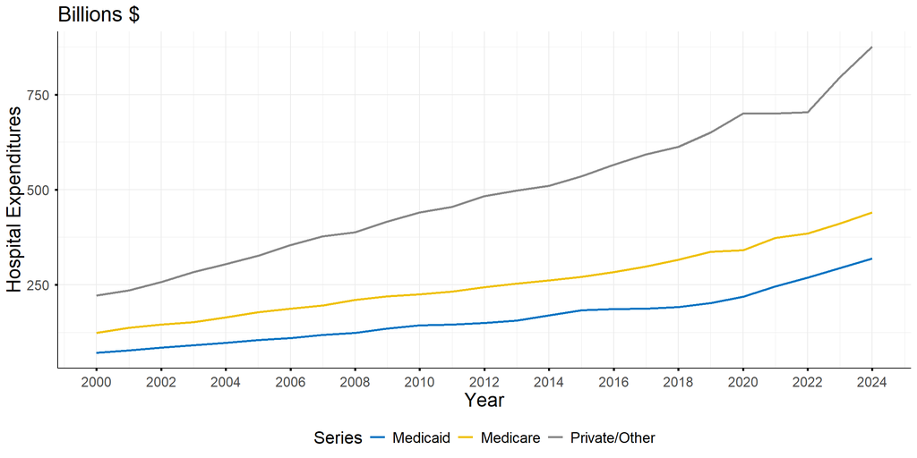

```r
# note: the total matches them to rounding error.

# plot
exp |>
  rename(`Private/Other` = Other) |>
  select(-total) |>
  pivot_longer(
    cols = !year,
    names_to = 'Series',
    values_to = 'Value'
  ) |>
  ggplot(aes(x = year, color = Series, y = Value)) +
  # geom_point(size = 3) +
  geom_line(linewidth = 1.05) +
  labs(
    y = 'Hospital Expenditures',
    x = 'Year',
    subtitle = 'Billions $'
  ) +
  scale_color_manual(values = ggpubr::get_palette('jco', 4)) +
  scale_x_continuous(
    breaks = seq(min(exp$year),
                 max(exp$year),
                 by = 2))
```

```r
DT::datatable(exp, caption = 'Hospital Expenditures (Billions)', rownames = F,
              extensions = 'Buttons',
              options = list(
                dom = 'Bfrtip',
                buttons = c('copy', 'csv', 'excel')
              ))
```

| year | total | Medicare | Medicaid | Other |
| --- | --- | --- | --- | --- |
| 2000 | 415.5 | 123 | 71.1 | 221.4 |
| 2001 | 449.3 | 136.8 | 77.6 | 234.9 |
| 2002 | 486.5 | 145 | 84.7 | 256.8 |
| 2003 | 525.9 | 152.2 | 90.6 | 283.1 |
| 2004 | 565.4000000000001 | 164 | 97.3 | 304.1 |
| 2005 | 608.6 | 177.8 | 104.3 | 326.5 |
| 2006 | 651.2 | 187 | 109.4 | 354.8 |
| 2007 | 691.9000000000001 | 196.1 | 118 | 377.8 |
| 2008 | 721.7 | 209.9 | 123.7 | 388.1 |
| 2009 | 771 | 219.2 | 135.1 | 416.7 |

[output cut: 15 more lines]

```r
rm(list = setdiff(ls(), c('exp', 'ppi', 'ppi_yearly')))
```

### % YoY Change in Total Expenditures by Payer-Type (Annual)

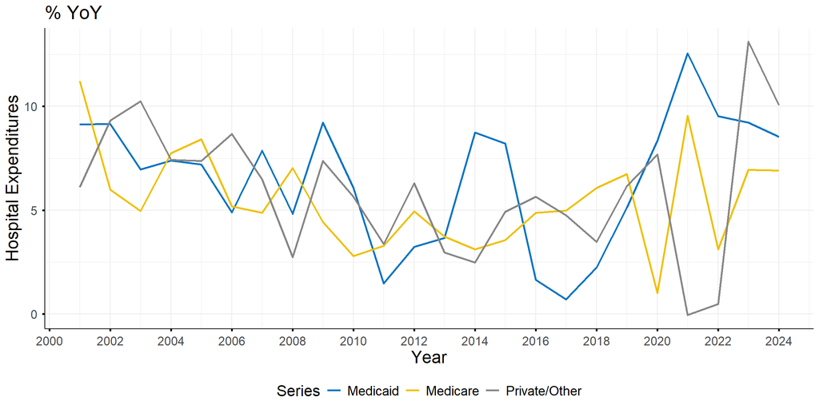

```r
# plot
exp |>
  mutate(
    Medicare = 100*(Medicare - lag(Medicare, 1)) / lag(Medicare, 1),
    Medicaid = 100 * (Medicaid - lag(Medicaid, 1)) / lag(Medicaid, 1),
    Other = 100 * (Other - lag(Other, 1)) / lag(Other, 1)
  ) |>
  rename(`Private/Other` = Other) |>
  select(-total) |>
  na.omit() |>
  pivot_longer(
    cols = !year,
    names_to = 'Series',
    values_to = 'Value'
  ) |>
  ggplot(aes(x = year, color = Series, y = Value)) +
  # geom_point(size = 3) +
  geom_line(linewidth = 1.05) +
  labs(
    y = 'Hospital Expenditures',
    x = 'Year',
    subtitle = '% YoY'
  ) +
  scale_color_manual(values = ggpubr::get_palette('jco', 4)) +
  scale_x_continuous(
    breaks = seq(min(exp$year),
                 max(exp$year),
                 by = 2))
```

The expenditure data are annual here. We will change this to monthly data by creating a sequence of monthly dates from January 2000 to December 2024, storing the `year` of each month, and merging the annual expenditure data using this `year` variable.

### Total Expenditures by Payer-Type (Monthly)

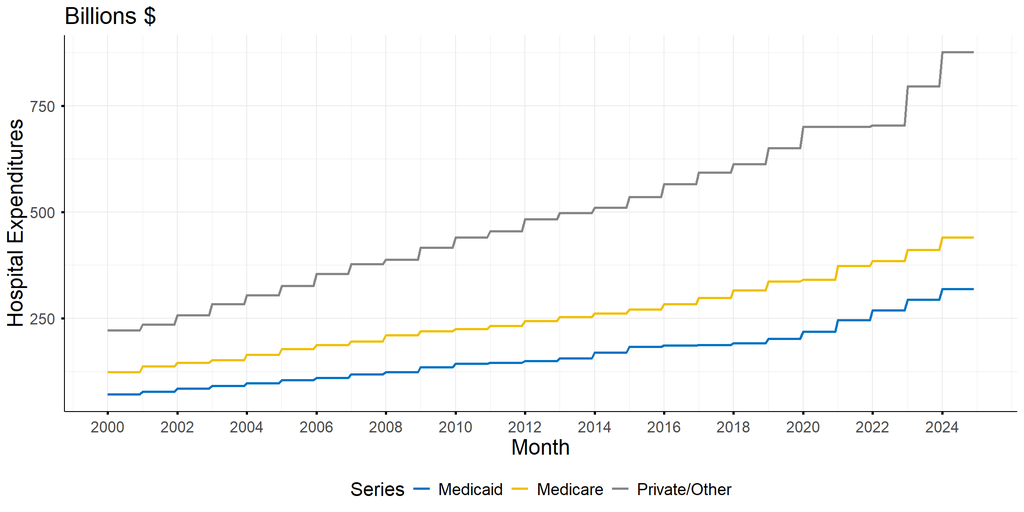

```r
exp_monthly = data.frame(
  date = seq.Date(as.Date('2000-01-01'), as.Date('2024-12-01'), by = 'month')
) |>
  mutate(
    year = year(date)
  ) |>
  left_join(exp, by = 'year')

exp_monthly |>
  rename(`Private/Other` = Other) |>
  select(-total, -year) |>
  pivot_longer(
    cols = !date,
    names_to = 'Series',
    values_to = 'Value'
  ) |>
  ggplot(aes(x = date, color = Series, y = Value)) +
  geom_line(linewidth = 1.05) +
  labs(
    y = 'Hospital Expenditures',
    x = 'Month',
    subtitle = 'Billions $'
  ) +
  scale_color_manual(values = ggpubr::get_palette('jco', 3)) +
  scale_x_date(
    breaks = seq(min(exp_monthly$date), max(exp_monthly$date), by = "2 years"),
    date_labels = "%Y"
  )
```

### % YoY Change in Total Expenditures by Payer-Type (Monthly)

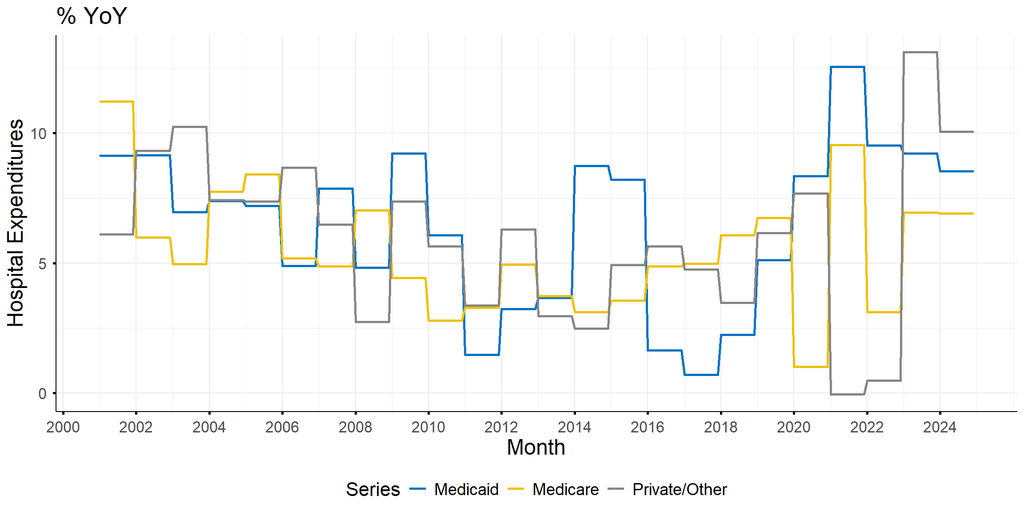

```r
exp_monthly |>
  select(-total, -year) |>
  mutate(
    Medicare = 100 * (Medicare - lag(Medicare, 12)) / lag(Medicare, 12),
    Medicaid = 100 * (Medicaid - lag(Medicaid, 12)) / lag(Medicaid, 12),
    Other = 100 * (Other - lag(Other, 12)) / lag(Other, 12)
  ) |>
    rename(`Private/Other` = Other) |>
  pivot_longer(
    cols = !date,
    names_to = 'Series',
    values_to = 'Value'
  ) |>
  na.omit() |>
  ggplot(aes(x = date, color = Series, y = Value)) +
  geom_line(linewidth = 1.05) +
  labs(
    y = 'Hospital Expenditures',
    x = 'Month',
    subtitle = '% YoY'
    ) +
  scale_color_manual(values = ggpubr::get_palette('jco', 3)) +
  scale_x_date(
    breaks = seq(min(exp_monthly$date), max(exp_monthly$date), by = "2 years"),
    date_labels = "%Y"
  )
```

Next, we compute the expenditure **shares** of each category.

### Expenditure Shares by Payer-Type (Monthly)

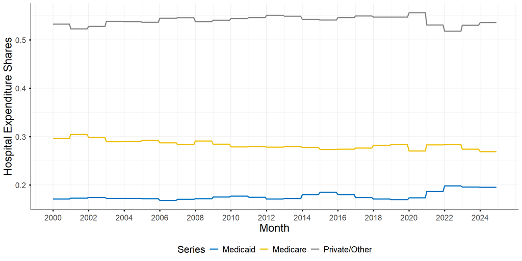

```r
exp_monthly = exp_monthly |>
  mutate(
    shr_Medicare = Medicare / total,
    shr_Medicaid = Medicaid/total,
    shr_Other = Other / total
  )

exp_monthly |>
  rename(`shr_Private/Other` = shr_Other) |>
  select(date, contains('shr')) |>
  pivot_longer(
    cols = !date,
    names_to = 'Series',
    values_to = 'Value'
  ) |>
  mutate(
    Series = str_replace_all(Series, 'shr_', '')
  ) |>
  ggplot(aes(x = date, color = Series, y = Value)) +
  # geom_point() +
  geom_line(linewidth = 1.05) +
  labs(
    y = 'Hospital Expenditure Shares',
    x = 'Month'
  ) +
  scale_color_manual(values = ggpubr::get_palette('jco', 3)) +
  scale_x_date(
    breaks = seq(min(exp_monthly$date), max(exp_monthly$date), by = "2 years"),
    date_labels = "%Y"
  )
```

### Expenditure Shares by Payer-Type % YoY (Monthly)

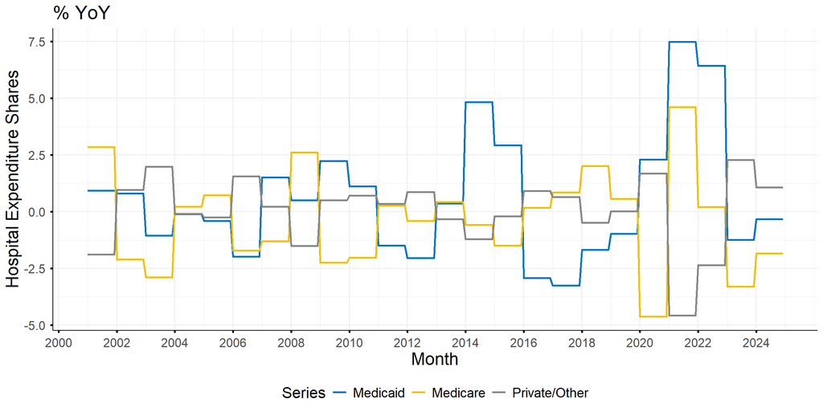

```r
exp_monthly |>
  mutate(
    shr_Medicare = 100*(shr_Medicare - lag(shr_Medicare, 12))/ lag(shr_Medicare, 12),
    shr_Medicaid = 100*(shr_Medicaid - lag(shr_Medicaid, 12))/ lag(shr_Medicaid, 12),
    shr_Other = 100*(shr_Other - lag(shr_Other, 12))/ lag(shr_Other, 12)
  )|>
  na.omit() |>
  rename(`shr_Private/Other` = shr_Other) |>
  select(date, contains('shr')) |>
  pivot_longer(
    cols = !date,
    names_to = 'Series',
    values_to = 'Value'
  ) |>
  mutate(
    Series = str_replace_all(Series, 'shr_', '')
  ) |>
  ggplot(aes(x = date, color = Series, y = Value)) +
  # geom_point() +
  geom_line(linewidth = 1.05) +
  labs(
    y = 'Hospital Expenditure Shares',
    x = 'Month',
    subtitle = '% YoY'
  ) +
  scale_color_manual(values = ggpubr::get_palette('jco', 3)) +
  scale_x_date(
    breaks = seq(min(exp_monthly$date), max(exp_monthly$date), by = "2 years"),
    date_labels = "%Y"
  )
```

### Expenditure Shares by Payer-Type % YoY (Annual)

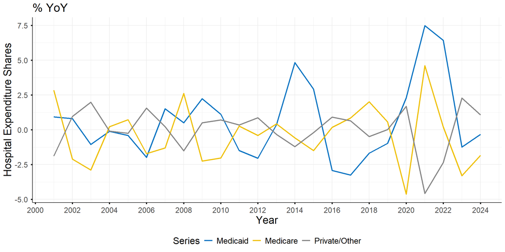

```r
exp |>
  mutate(
    shr_Medicare = Medicare / total,
    shr_Medicaid = Medicaid / total,
    shr_Other = Other / total,
    shr_Medicare = 100*(shr_Medicare - lag(shr_Medicare, 1))/ lag(shr_Medicare, 1),
    shr_Medicaid = 100*(shr_Medicaid - lag(shr_Medicaid, 1))/ lag(shr_Medicaid, 1),
    shr_Other = 100*(shr_Other - lag(shr_Other, 1))/ lag(shr_Other, 1)
  )|>
  na.omit() |>
  rename(`shr_Private/Other` = shr_Other) |>
  select(year, contains('shr')) |>
  pivot_longer(
    cols = !year,
    names_to = 'Series',
    values_to = 'Value'
  ) |>
  mutate(
    Series = str_replace_all(Series, 'shr_', '')
  ) |>
  ggplot(aes(x = year, color = Series, y = Value)) +
  # geom_point() +
  geom_line(linewidth = 1.05) +
  labs(
    y = 'Hospital Expenditure Shares',
    x = 'Year',
    subtitle = '% YoY'
  ) +
  scale_color_manual(values = ggpubr::get_palette('jco', 3)) +
  scale_x_continuous(
    breaks = seq(min(exp$year), max(exp$year), by = 2)
  )
```

## Overall Hospital Inflation

### Monthly

```r
# convert ppi to long format
ppi_long = ppi |>
  pivot_longer(
    cols = !date,
    names_to = 'payerType',
    values_to = 'ppi'
  ) |>
  mutate(
    payerType = str_replace_all(payerType, 'ppi_', '')
  )

# convert exp to long format
exp_monthly_long = exp_monthly |>
  select(date, contains('shr')) |>
  pivot_longer(
    cols = !date,
    names_to = 'payerType',
    values_to = 'wt'
  ) |>
  mutate(
    payerType = str_replace_all(payerType, 'shr_', '')
  )

# combine the data
inflation = inner_join(exp_monthly_long, ppi_long, by = c('date', 'payerType')) |>
  # compute overall inflation
  group_by(date) |>
  summarise(
    P_t = sum(wt*ppi)
  ) |>
  ungroup() |>
  mutate(
    pi_t = 100*(P_t - lag(P_t, 12)) / lag(P_t, 12)
  )

fwrite(inflation, here('data/analysis/industry_based_inflation.csv'))

# read in overall healthcare services inflation
pce = import_haver(
  series = c('jcxfebm@USECON', 'jcsdm@usna'), eop = F
) |>
  rename(
    `Core PCE` = jcxfebm,
    `Healthcare` = jcsdm
  ) |>
  mutate(
    `Core PCE` = 100*(`Core PCE` - lag(`Core PCE`, 12)) / lag(`Core PCE`, 12),
    `Healthcare` = 100*(Healthcare - lag(Healthcare, 12)) / lag(Healthcare, 12)
  )
```

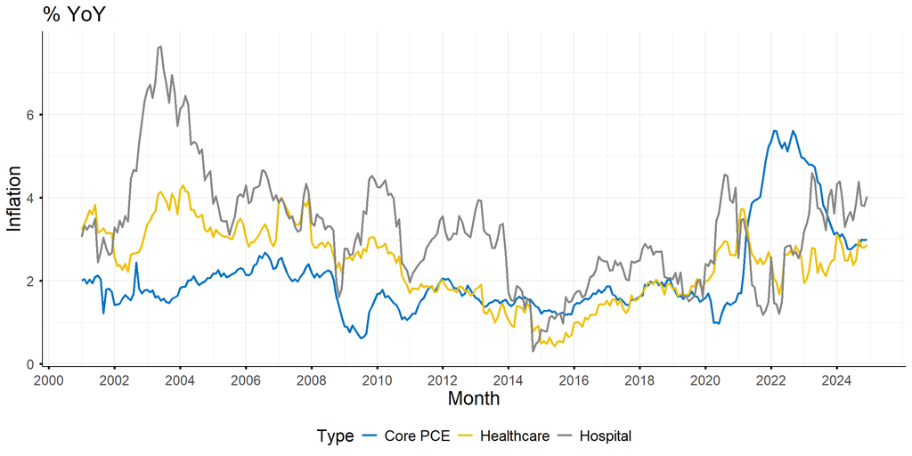

Full Sample

```r
# plot overall
inflation |>
  left_join(pce, by = 'date')  |>
  rename(Hospital = pi_t) |>
  select(date, Hospital, `Core PCE`, Healthcare) |>
  na.omit() |>
  pivot_longer(
    cols = !date,
    names_to = 'Type',
    values_to = 'Inflation'
  ) |>
  ggplot(aes(x = date, y = Inflation, color = Type)) +
  geom_line(linewidth = 1.05) +
  # geom_hline(yintercept = mean(inflation$pi_t, na.rm = T), linetype = 'dashed') +
  labs(
    x = 'Month',
    y = 'Inflation',
    subtitle = '% YoY'
  ) +
    scale_x_date(
    breaks = seq(min(exp_monthly$date), max(exp_monthly$date), by = "2 years"),
    date_labels = "%Y"
  ) +
    scale_color_manual(values = ggpubr::get_palette('jco', 3))
```

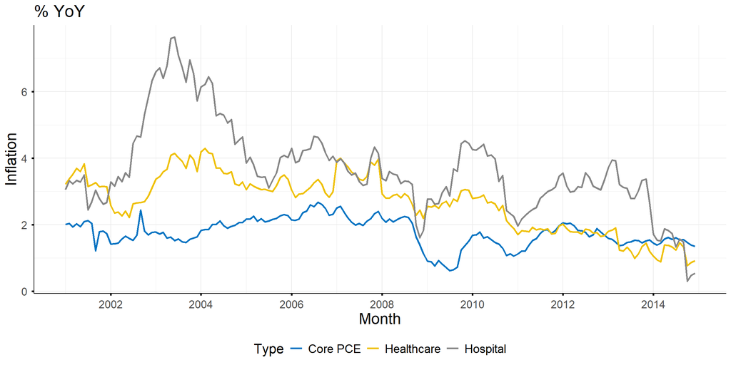

Pre-2015 Sample

```r
# plot overall
inflation |>
  left_join(pce, by = 'date')  |>
  rename(Hospital = pi_t) |>
  select(date, Hospital, `Core PCE`, Healthcare) |>
  na.omit() |>
  pivot_longer(
    cols = !date,
    names_to = 'Type',
    values_to = 'Inflation'
  ) |>
  filter(date < '2015-01-01') |>
  ggplot(aes(x = date, y = Inflation, color = Type)) +
  geom_line(linewidth = 1.05) +
  # geom_hline(yintercept = mean(inflation$pi_t, na.rm = T), linetype = 'dashed') +
  labs(
    x = 'Month',
    y = 'Inflation',
    subtitle = '% YoY'
  ) +
    scale_x_date(
    breaks = seq(min(exp_monthly$date), max(exp_monthly$date), by = "2 years"),
    date_labels = "%Y"
  ) +
    scale_color_manual(values = ggpubr::get_palette('jco', 3))
```

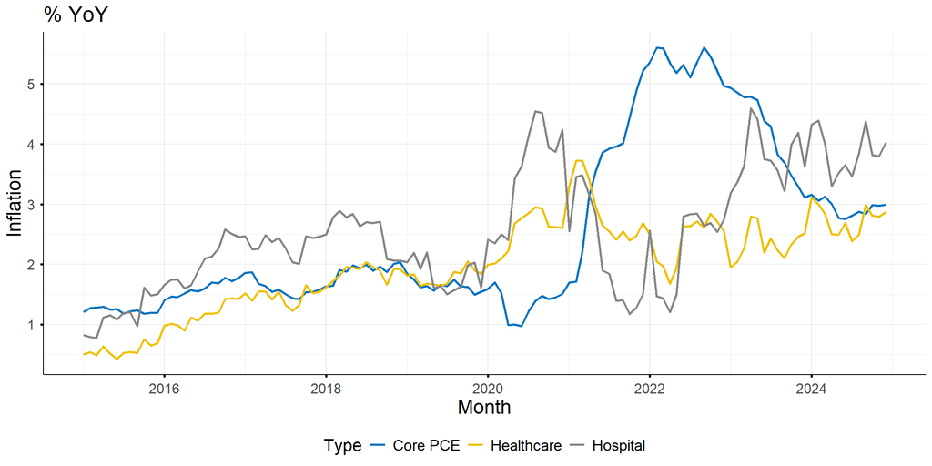

Post-2015 Sample

```r
# plot overall
inflation |>
  left_join(pce, by = 'date')  |>
  rename(Hospital = pi_t) |>
  select(date, Hospital, `Core PCE`, Healthcare) |>
  na.omit() |>
  pivot_longer(
    cols = !date,
    names_to = 'Type',
    values_to = 'Inflation'
  ) |>
  filter(date >= '2015-01-01') |>
  ggplot(aes(x = date, y = Inflation, color = Type)) +
  geom_line(linewidth = 1.05) +
  # geom_hline(yintercept = mean(inflation$pi_t, na.rm = T), linetype = 'dashed') +
  labs(
    x = 'Month',
    y = 'Inflation',
    subtitle = '% YoY'
  ) +
    scale_x_date(
    breaks = seq(min(exp_monthly$date), max(exp_monthly$date), by = "2 years"),
    date_labels = "%Y"
  ) +
    scale_color_manual(values = ggpubr::get_palette('jco', 3))
```

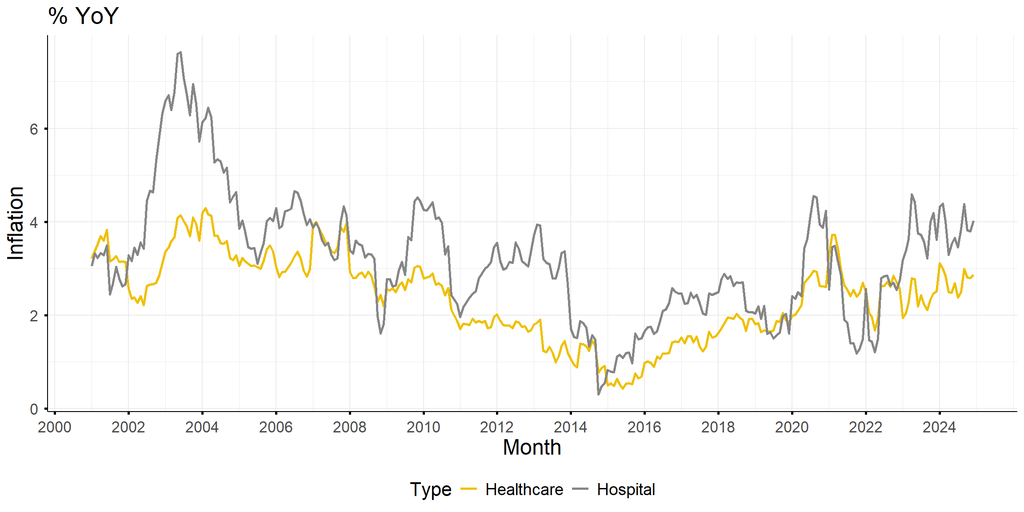

Full Sample Partitioned Pairwise

```r
legend = c('Core PCE' = '#0073C2FF',
           'Healthcare' = '#EFC000FF',
           'Hospital' = '#868686ff')
# healthcare vs. core pce
inflation |>
  left_join(pce, by = 'date')  |>
  rename(Hospital = pi_t) |>
  select(date, Healthcare, Hospital) |>
  na.omit() |>
  pivot_longer(
    cols = !date,
    names_to = 'Type',
    values_to = 'Inflation'
  ) |>
  ggplot(aes(x = date, y = Inflation, color = Type)) +
  geom_line(linewidth = 1.05) +
  # geom_hline(yintercept = mean(inflation$pi_t, na.rm = T), linetype = 'dashed') +
  labs(
    x = 'Month',
    y = 'Inflation',
    subtitle = '% YoY'
  ) +
    scale_x_date(
    breaks = seq(min(exp_monthly$date), max(exp_monthly$date), by = "2 years"),
    date_labels = "%Y"
  ) +
    scale_color_manual(values = legend)
```

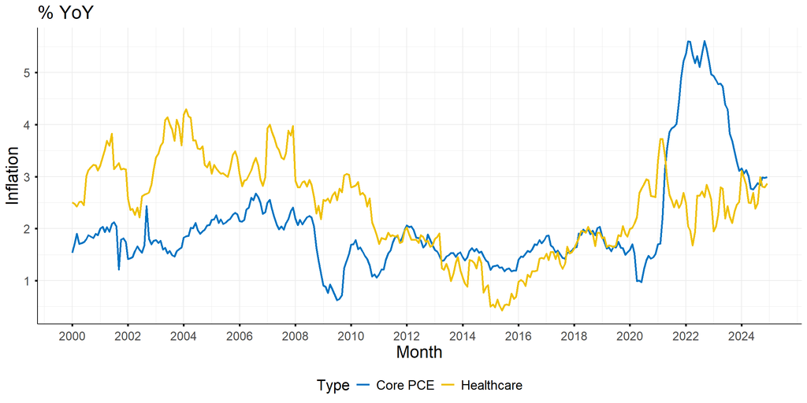

Full Sample Partitioned Pairwise

```r
# healthcare vs. hospital
inflation |>
  left_join(pce, by = 'date')  |>
  rename(Hospital = pi_t) |>
  select(date, `Core PCE`, Healthcare) |>
  na.omit() |>
  pivot_longer(
    cols = !date,
    names_to = 'Type',
    values_to = 'Inflation'
  ) |>
  ggplot(aes(x = date, y = Inflation, color = Type)) +
  geom_line(linewidth = 1.05) +
  # geom_hline(yintercept = mean(inflation$pi_t, na.rm = T), linetype = 'dashed') +
  labs(
    x = 'Month',
    y = 'Inflation',
    subtitle = '% YoY'
  ) +
    scale_x_date(
    breaks = seq(min(exp_monthly$date), max(exp_monthly$date), by = "2 years"),
    date_labels = "%Y"
  ) +
    scale_color_manual(values = legend)
```

### Annual

We repeat the same exercise at the annual frequency. We compute expenditure shares from the annual CMS data directly (rather than spreading them across months) and take the annual average of the monthly PPI series. The weighted price index $P_t = \sum_i w_{i,t} \times p_{i,t}$ is then computed year-by-year, and year-over-year inflation is $\pi_t = 100 \times (P_t - P_{t-1}) / P_{t-1}$.

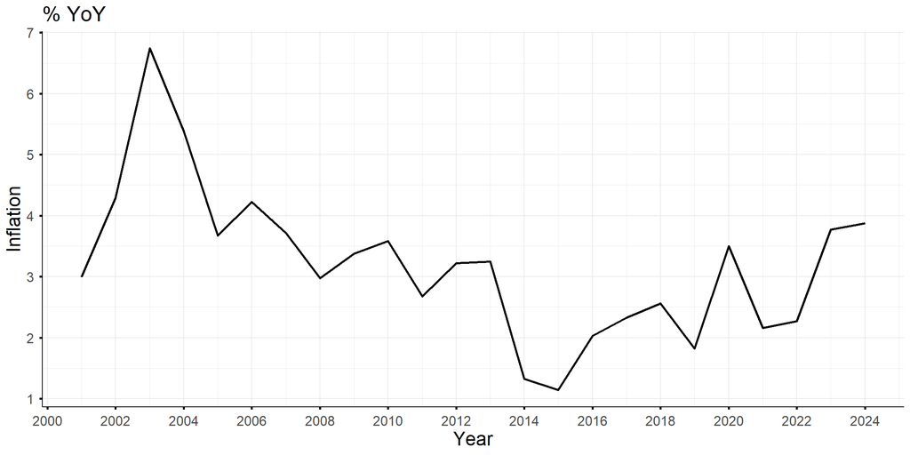

```r
# store annual shares and pivot longer
exp_year_long = exp |>
  mutate(shr_Medicare = Medicare / total,
         shr_Medicaid = Medicaid / total,
         shr_Other = Other / total) |>
  select(year, contains('shr'))  |>
  pivot_longer(
    cols = !year,
    names_to = 'payerType',
    values_to = 'wt'
  ) |>
  mutate(
    payerType = str_replace_all(payerType, 'shr_', '')
  ) |>
  mutate(
    year = as.integer(year)
  )

# store annual ppi long
ppi_yearly_long = ppi_yearly |>
  pivot_longer(
    cols = !year,
    names_to = 'payerType',
    values_to = 'ppi'
  ) |>
  mutate(
    payerType = str_replace_all(payerType, 'ppi_', '')
  )

# combine the data
inflation_annual = inner_join(exp_year_long, ppi_yearly_long, by = c('year', 'payerType')) |>
  # compute overall inflation
  group_by(year) |>
  summarise(
    P_t = sum(wt*ppi)
  ) |>
  ungroup() |>
  mutate(
    pi_t = 100*(P_t - lag(P_t, 1)) / lag(P_t, 1)
  )

fwrite(inflation_annual, here('data/analysis/industry_based_inflation_annual.csv'))



inflation_annual |>
  # left_join(pce, by = 'date')  |>
  rename(Hospital = pi_t) |>
  # select(date, Hospital, `Core PCE`, Healthcare) |>
  select(year, Hospital) |>
  na.omit() |>
  # pivot_longer(cols = !year,
  #              names_to = 'Type',
  #              values_to = 'Inflation') |>
  # ggplot(aes(x = date, y = Inflation, color = Type)) +
  ggplot(aes(x = year, y = Hospital)) +
  geom_line(linewidth = 1.05) +
  # geom_hline(yintercept = mean(inflation$pi_t, na.rm = T), linetype = 'dashed') +
  labs(x = 'Year', y = 'Inflation',
       subtitle = '% YoY') +
  scale_x_continuous(breaks = seq(min(exp_year_long$year), max(exp_year_long$year), by = 2))
```

```r
# scale_color_manual(values = ggpubr::get_palette('jco', 3))
```

## Industry Based Decomposition of Hospital Inflation (Monthly)

**Laspeyres Decomposition by Weights and Prices**

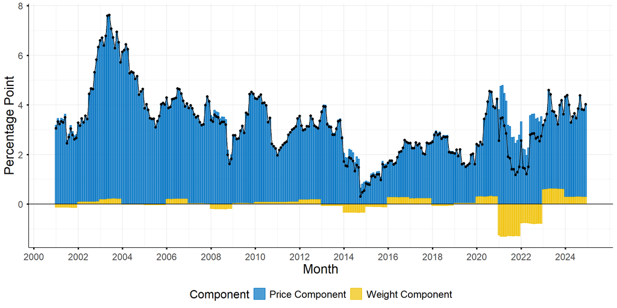

```r
legend = ggpubr::get_palette('jco', 2)
names(legend) = c('Price Component', 'Weight Component')
inner_join(exp_monthly_long, ppi_long, by = c('date', 'payerType')) |>
  # get price component of the laspeyres-style decomp
  group_by(payerType) |>
  mutate(
    price_component_L = lag(wt, 12) * (ppi - lag(ppi, 12)),
    weight_component_L = ppi * (wt - lag(wt, 12))
  ) |>
  ungroup() |>
  group_by(date) |>
  summarise(
    `Price Component` = sum(price_component_L, na.rm = T),
    `Weight Component` = sum(weight_component_L, na.rm = T)
  ) |>
  ungroup() |>
  # normalize by P_{t-k} to convert from level change to percentage change
  left_join(inflation, by = 'date') |>
  mutate(
    `Price Component`  = `Price Component`  / lag(P_t, 12) * 100,
    `Weight Component` = `Weight Component` / lag(P_t, 12) * 100,
    pi_t = pi_t
  ) |>
  pivot_longer(
    cols = c(`Price Component`, `Weight Component`),
    names_to = 'Component',
    values_to = 'Contribution'
  ) |>
  # check the inflation total matches pi_t
  group_by(date) |>
  mutate(check = sum(Contribution)) |>
  ungroup() |>
  mutate(flag = ifelse(round(check - pi_t, 5) == 0, F, T)) |>
  filter(date >= '2001-01-01') |>
  # summary()
  ggplot(aes(x = date)) +
  geom_col(aes(y = Contribution, color = Component, fill = Component), alpha = .7) +
  geom_point(aes(y = pi_t)) +
  geom_line(aes(y = pi_t), linetype = 'solid') +
  geom_hline(yintercept = 0, linetype = 'solid') +
  scale_color_manual(values = legend) +
  scale_fill_manual(values = legend) +
  scale_x_date(breaks = seq(min(exp_monthly$date), max(exp_monthly$date), by = "2 years"),
               date_labels = '%Y') +
  labs(x = 'Month', y = 'Percentage Point')
```

**Laspeyres Decomposition by Payer Type**

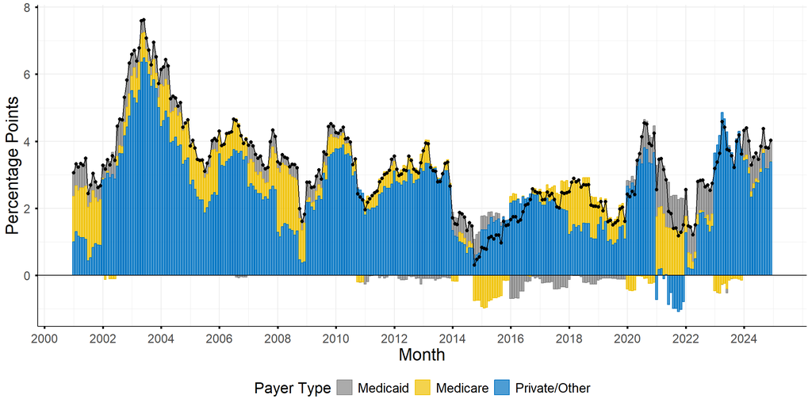

```r
legend = ggpubr::get_palette('jco', 3)
names(legend) = c('Private/Other', 'Medicare', 'Medicaid')
inner_join(exp_monthly_long, ppi_long, by = c('date', 'payerType')) |>
  mutate(
    payerType = ifelse(payerType == 'Other', 'Private/Other', payerType)
  ) |>
  # get price component of the laspeyres-style decomp
  group_by(payerType) |>
  mutate(
    price_component_L = lag(wt, 12) * (ppi - lag(ppi, 12)),
    weight_component_L = ppi * (wt - lag(wt, 12))
  ) |>
  ungroup() |>
  # store the contribution from each
  mutate(
    contribution_L = price_component_L + weight_component_L
  ) |>
  select(
    date, payerType, contribution_L
  ) |>
    arrange(payerType, date) |>
  # normalize by P_{t-k} to convert from level change to percentage change
  left_join(inflation, by = 'date') |>
  group_by(payerType) |>
  mutate(
    Contribution = contribution_L / lag(P_t, 12) * 100,
    pi_t = pi_t
  ) |>
  ungroup() |>
  # check the inflation total matches pi_t
  group_by(date) |>
  mutate(check = sum(Contribution)) |>
  ungroup() |>
  mutate(
    flag = ifelse(round(check - pi_t, 5) == 0, F, T)
  ) |>
  filter(date >= '2001-01-01') |>
  ggplot(aes(x = date)) +
  geom_col(aes(y = Contribution, color = payerType, fill = payerType), alpha = .7) +
  geom_point(aes(y = pi_t)) +
  geom_line(aes(y = pi_t), linetype = 'solid') +
  geom_hline(yintercept = 0, linetype = 'solid') +
  scale_color_manual(values = legend) +
  scale_fill_manual(values = legend) +
  scale_x_date(breaks = seq(min(exp_monthly$date), max(exp_monthly$date), by = "2 years"),
               date_labels = '%Y') +
  labs(
    x = 'Month',
    y = 'Percentage Points',
    fill = 'Payer Type',
    color = 'Payer Type'
  )
```

**Paasche Decomposition by Weights and Prices**

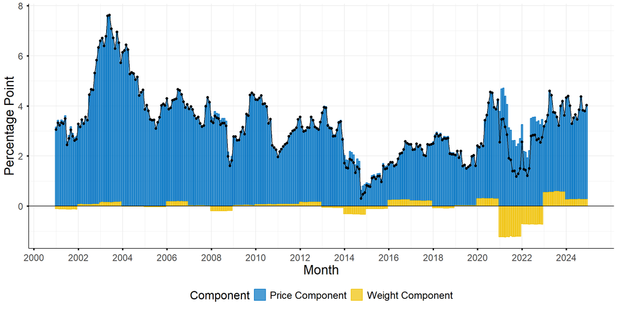

```r
legend = ggpubr::get_palette('jco', 2)
names(legend) = c('Price Component', 'Weight Component')
inner_join(exp_monthly_long, ppi_long, by = c('date', 'payerType')) |>
  # get price component of the paasche-style decomp
  group_by(payerType) |>
  mutate(
    price_component_P = wt * (ppi - lag(ppi, 12)),
    weight_component_P = lag(ppi, 12) * (wt - lag(wt, 12))
  ) |>
  ungroup() |>
  group_by(date) |>
  summarise(
    `Price Component` = sum(price_component_P, na.rm = T),
    `Weight Component` = sum(weight_component_P, na.rm = T)
  ) |>
  ungroup() |>
  # normalize by P_{t-k} to convert from level change to percentage change
  left_join(inflation, by = 'date') |>
  mutate(
    `Price Component`  = `Price Component`  / lag(P_t, 12) * 100,
    `Weight Component` = `Weight Component` / lag(P_t, 12) * 100,
    pi_t = pi_t
  ) |>
  pivot_longer(
    cols = c(`Price Component`, `Weight Component`),
    names_to = 'Component',
    values_to = 'Contribution'
  ) |>
  # check the inflation total matches pi_t
  group_by(date) |>
  mutate(check = sum(Contribution)) |>
  ungroup() |>
  mutate(
    flag = ifelse(round(check - pi_t, 5) == 0, F, T)
  ) |>
  filter(date >= '2001-01-01') |>
  # summary()
  ggplot(aes(x = date)) +
  geom_col(aes(y = Contribution, color = Component, fill = Component), alpha = .7) +
  geom_point(aes(y = pi_t)) +
  geom_line(aes(y = pi_t), linetype = 'solid') +
  geom_hline(yintercept = 0, linetype = 'solid') +
  scale_color_manual(values = legend) +
  scale_fill_manual(values = legend) +
    scale_x_date(breaks = seq(min(exp_monthly$date), max(exp_monthly$date), by = "2 years"),
               date_labels = '%Y') +
  labs(
    x = 'Month',
    y = 'Percentage Point'
  )
```

**Paasche Decomposition by Payer Type**

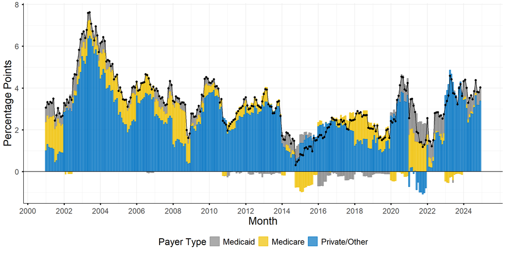

```r
legend = ggpubr::get_palette('jco', 3)
names(legend) = c('Private/Other', 'Medicare', 'Medicaid')
inner_join(exp_monthly_long, ppi_long, by = c('date', 'payerType')) |>
  mutate(
    payerType = ifelse(payerType == 'Other', 'Private/Other', payerType)
  ) |>
  # get price component of the paasche-style decomp
  group_by(payerType) |>
  mutate(
    price_component_P = wt * (ppi - lag(ppi, 12)),
    weight_component_P = lag(ppi, 12) * (wt - lag(wt, 12))
  ) |>
  ungroup() |>
  # store the contribution from each
  mutate(
    contribution_P = price_component_P + weight_component_P
  ) |>
  select(
    date, payerType, contribution_P
  ) |>
    arrange(payerType, date) |>
  # normalize by P_{t-k} to convert from level change to percentage change
  left_join(inflation, by = 'date') |>
  group_by(payerType) |>
  mutate(
    Contribution = contribution_P / lag(P_t, 12) * 100,
    pi_t = pi_t
  ) |>
  ungroup() |>
  # check the inflation total matches pi_t
  group_by(date) |>
  mutate(check = sum(Contribution)) |>
  ungroup() |>
  mutate(
    flag = ifelse(round(check - pi_t, 5) == 0, F, T)
  ) |>
  filter(date >= '2001-01-01') |>
  ggplot(aes(x = date)) +
  geom_col(aes(y = Contribution, color = payerType, fill = payerType), alpha = .7) +
  geom_point(aes(y = pi_t)) +
  geom_line(aes(y = pi_t), linetype = 'solid') +
  geom_hline(yintercept = 0, linetype = 'solid') +
  scale_color_manual(values = legend) +
  scale_fill_manual(values = legend) +
    scale_x_date(breaks = seq(min(exp_monthly$date), max(exp_monthly$date), by = "2 years"),
               date_labels = '%Y') +
  labs(
    x = 'Month',
    y = 'Percentage Points',
    fill = 'Payer Type',
    color = 'Payer Type'
  )
```

## Industry Based Decomposition of Hospital Inflation (Annual)

We now decompose annual hospital inflation into price and weight components using the same Laspeyres and Paasche identities applied to the annual data. The lag is 1 year rather than 12 months. Each component is normalized by $P_{t-1}$ and multiplied by 100 so the contributions are in percentage points and sum to $\pi_t$.

**Laspeyres Decomposition by Weights and Prices**

The Laspeyres decomposition evaluates price changes at prior-year weights and weight changes at current-year prices: $\Delta P_t^L = \sum_i w_{i,t-1} \Delta p_i + \sum_i \Delta w_i \, p_{i,t}$.

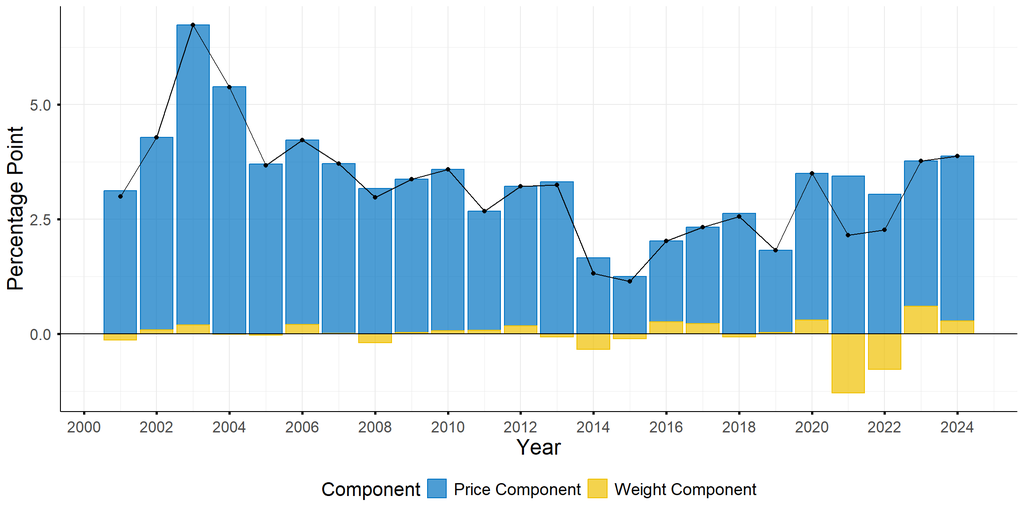

```r
legend = ggpubr::get_palette('jco', 2)
names(legend) = c('Price Component', 'Weight Component')
inner_join(exp_year_long, ppi_yearly_long, by = c('year', 'payerType')) |>
  # get price component of the laspeyres-style decomp
  group_by(payerType) |>
  mutate(
    price_component_L = lag(wt, 1) * (ppi - lag(ppi, 1)),
    weight_component_L = ppi * (wt - lag(wt, 1))
  ) |>
  ungroup() |>
  group_by(year) |>
  summarise(
    `Price Component` = sum(price_component_L, na.rm = T),
    `Weight Component` = sum(weight_component_L, na.rm = T)
  ) |>
  ungroup() |>
  # normalize by P_{t-k} to convert from level change to percentage change
  left_join(inflation_annual, by = 'year') |>
  mutate(
    `Price Component`  = `Price Component`  / lag(P_t, 1) * 100,
    `Weight Component` = `Weight Component` / lag(P_t, 1) * 100,
    pi_t = pi_t
  ) |>
  pivot_longer(
    cols = c(`Price Component`, `Weight Component`),
    names_to = 'Component',
    values_to = 'Contribution'
  ) |>
  # check the inflation total matches pi_t
  group_by(year) |>
  mutate(check = sum(Contribution)) |>
  ungroup() |>
  mutate(
    flag = ifelse(round(check - pi_t, 5) == 0, F, T)
  ) |>
  filter(year >= 2001) |>
  # summary()
  ggplot(aes(x = year)) +
  geom_col(aes(y = Contribution, color = Component, fill = Component), alpha = .7) +
  geom_point(aes(y = pi_t)) +
  geom_line(aes(y = pi_t), linetype = 'solid') +
  geom_hline(yintercept = 0, linetype = 'solid') +
  scale_color_manual(values = legend) +
  scale_fill_manual(values = legend) +
  scale_x_continuous(
    breaks = seq(min(exp_year_long$year), max(exp_year_long$year), by = 2)
  ) +
  labs(
    x = 'Year',
    y = 'Percentage Point'
  )
```

**Laspeyres Decomposition by Payer Type**

Rather than splitting into price vs. weight, we aggregate each payer’s total contribution (price + weight) to show how much of overall inflation is attributable to Medicare, Medicaid, and Private/Other.

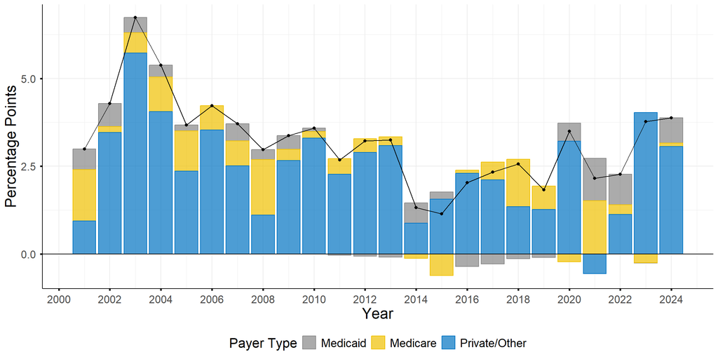

```r
legend = ggpubr::get_palette('jco', 3)
names(legend) = c('Private/Other', 'Medicare', 'Medicaid')
inner_join(exp_year_long, ppi_yearly_long, by = c('year', 'payerType')) |>
  mutate(payerType = ifelse(payerType == 'Other', 'Private/Other', payerType)) |>
  # get price component of the laspeyres-style decomp
  group_by(payerType) |>
  mutate(
    price_component_L = lag(wt, 1) * (ppi - lag(ppi, 1)),
    weight_component_L = ppi * (wt - lag(wt, 1))
  ) |>
  ungroup() |>
  # store the contribution from each
  mutate(
    contribution_L = price_component_L + weight_component_L
  ) |>
  select(
    year, payerType, contribution_L
  ) |>
    arrange(payerType, year) |>
  # normalize by P_{t-k} to convert from level change to percentage change
  left_join(inflation_annual, by = 'year') |>
  group_by(payerType) |>
  mutate(
    Contribution = contribution_L / lag(P_t, 1) * 100,
    pi_t = pi_t
  ) |>
  ungroup() |>
  # check the inflation total matches pi_t
  group_by(year) |>
  mutate(check = sum(Contribution)) |>
  ungroup() |>
  mutate(
    flag = ifelse(round(check - pi_t, 5) == 0, F, T)
  ) |>
  filter(year >= 2001) |>
  ggplot(aes(x = year)) +
  geom_col(aes(y = Contribution, color = payerType, fill = payerType), alpha = .7) +
  geom_point(aes(y = pi_t)) +
  geom_line(aes(y = pi_t), linetype = 'solid') +
  geom_hline(yintercept = 0, linetype = 'solid') +
  scale_color_manual(values = legend) +
  scale_fill_manual(values = legend) +
  scale_x_continuous(
    breaks = seq(min(exp_year_long$year), max(exp_year_long$year), by = 2)
  ) +
  labs(
    x = 'Year',
    y = 'Percentage Points',
    fill = 'Payer Type',
    color = 'Payer Type'
  )
```

**Paasche Decomposition by Weights and Prices**

The Paasche decomposition evaluates price changes at current-year weights and weight changes at prior-year prices: $\Delta P_t^P = \sum_i w_{i,t} \Delta p_i + \sum_i \Delta w_i \, p_{i,t-1}$.

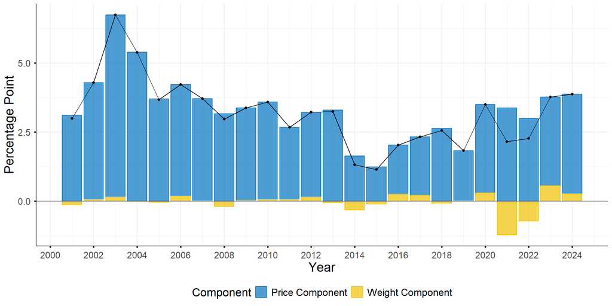

```r
legend = ggpubr::get_palette('jco', 2)
names(legend) = c('Price Component', 'Weight Component')
inner_join(exp_year_long, ppi_yearly_long, by = c('year', 'payerType')) |>
  # get price component of the paasche-style decomp
  group_by(payerType) |>
  mutate(
    price_component_P = wt * (ppi - lag(ppi, 1)),
    weight_component_P = lag(ppi, 1) * (wt - lag(wt, 1))
  ) |>
  ungroup() |>
  group_by(year) |>
  summarise(
    `Price Component` = sum(price_component_P, na.rm = T),
    `Weight Component` = sum(weight_component_P, na.rm = T)
  ) |>
  ungroup() |>
  # normalize by P_{t-k} to convert from level change to percentage change
  left_join(inflation_annual, by = 'year') |>
  mutate(
    `Price Component`  = `Price Component`  / lag(P_t, 1) * 100,
    `Weight Component` = `Weight Component` / lag(P_t, 1) * 100,
    pi_t = pi_t
  ) |>
  pivot_longer(
    cols = c(`Price Component`, `Weight Component`),
    names_to = 'Component',
    values_to = 'Contribution'
  ) |>
  # check the inflation total matches pi_t
  group_by(year) |>
  mutate(check = sum(Contribution)) |>
  ungroup() |>
  mutate(
    flag = ifelse(round(check - pi_t, 5) == 0, F, T)
  ) |>
  filter(year >= 2001) |>
  # summary()
  ggplot(aes(x = year)) +
  geom_col(aes(y = Contribution, color = Component, fill = Component), alpha = .7) +
  geom_point(aes(y = pi_t)) +
  geom_line(aes(y = pi_t), linetype = 'solid') +
  geom_hline(yintercept = 0, linetype = 'solid') +
  scale_color_manual(values = legend) +
  scale_fill_manual(values = legend) +
  scale_x_continuous(
    breaks = seq(min(exp_year_long$year), max(exp_year_long$year), by = 2)
  ) +
  labs(
    x = 'Year',
    y = 'Percentage Point'
  )
```

**Paasche Decomposition by Payer Type**

Same payer-level aggregation as the Laspeyres tab, but using the Paasche identity so that price effects are evaluated at current weights and weight effects at prior-year prices.

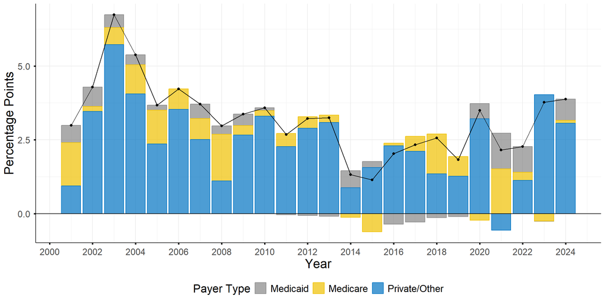

```r
legend = ggpubr::get_palette('jco', 3)
names(legend) = c('Private/Other', 'Medicare', 'Medicaid')
inner_join(exp_year_long, ppi_yearly_long, by = c('year', 'payerType')) |>
  mutate(payerType = ifelse(payerType == 'Other', 'Private/Other', payerType)) |>
  # get price component of the paasche-style decomp
  group_by(payerType) |>
  mutate(
    price_component_P = wt * (ppi - lag(ppi, 1)),
    weight_component_P = lag(ppi, 1) * (wt - lag(wt, 1))
  ) |>
  ungroup() |>
  # store the contribution from each
  mutate(
    contribution_P = price_component_P + weight_component_P
  ) |>
  select(
    year, payerType, contribution_P
  ) |>
    arrange(payerType, year) |>
  # normalize by P_{t-k} to convert from level change to percentage change
  left_join(inflation_annual, by = 'year') |>
  group_by(payerType) |>
  mutate(
    Contribution = contribution_P / lag(P_t, 1) * 100,
    pi_t = pi_t
  ) |>
  ungroup() |>
  # check the inflation total matches pi_t
  group_by(year) |>
  mutate(check = sum(Contribution)) |>
  ungroup() |>
  mutate(
    flag = ifelse(round(check - pi_t, 5) == 0, F, T)
  ) |>
  filter(year >= 2001) |>
  ggplot(aes(x = year)) +
  geom_col(aes(y = Contribution, color = payerType, fill = payerType), alpha = .7) +
  geom_point(aes(y = pi_t)) +
  geom_line(aes(y = pi_t), linetype = 'solid') +
  geom_hline(yintercept = 0, linetype = 'solid') +
  scale_color_manual(values = legend) +
  scale_fill_manual(values = legend) +
  scale_x_continuous(breaks = seq(min(exp_year_long$year), max(exp_year_long$year), by = 2)) +
  labs(x = 'Year',
       y = 'Percentage Points',
       fill = 'Payer Type',
       color = 'Payer Type')
```

## Commodity-Based Hospital Inflation

### Producer Price Index (PPI)

In the commodity-based categorization of the PPI, there are categories for “Hospital outpatient care” and “Hospital inpatient care”, each of which have a subcategory for “General medical and surgical hospitals”. This subcategory for general hospitals has price indexes by payer type, just as detailed for the previous method. The overall categorization looks like:

1. Hospital **outpatient** care
   1. General medical and surgical hospitals
   2. Medicare patients
   2. Medicaid patients
   3. Private insurance and all other patients
2. Hospital **inpatient** care
   1. General medical and surgical hospitals
   2. Medicare patients
   2. Medicaid patients
   3. Private insurance and all other patients

We need to aggregate the indexes of the same payer type to calculate the overall hospital services price index by that payer.

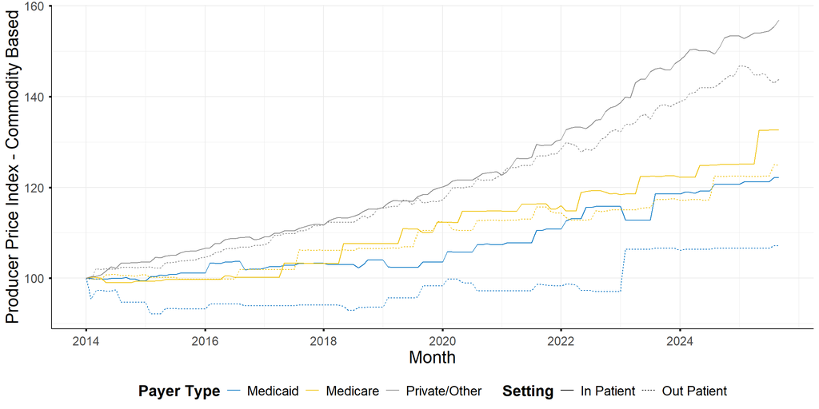

```r
rm(list=ls())
# read haver ppi
ppi = import_haver(series = c("P512101B@PPI",
                              "P511104B@PPI",
                              "P512101C@PPI",
                              "P511104C@PPI",
                              "P512101D@PPI",
                              "P511104D@PPI"
                              ),
                   eop = F) |>
  rename(ppi_Medicare_in = p512101b,
         ppi_Medicare_out = p511104b,
         ppi_Medicaid_in = p512101c,
         ppi_Medicaid_out = p511104c,
         ppi_Other_in = p512101d,
         ppi_Other_out = p511104d)

ppi |>
  pivot_longer(cols = !date,
               names_to = 'Series',
               values_to = 'Value') |>
  mutate(
    Setting = substr(Series, str_length(Series) - 2, str_length(Series)),
    Setting = str_replace_all(Setting, '_', ''),
    Setting = ifelse(Setting == 'in', 'In Patient', 'Out Patient'),
    `Payer Type` = str_replace_all(Series, 'ppi_|_in|_out', ''),
    `Payer Type` = ifelse(`Payer Type` == 'Other', 'Private/Other', `Payer Type`)
  ) |>
  ggplot(aes(
    x = date,
    color = `Payer Type`,
    linetype = Setting,
    y = Value
  )) +
  geom_line() +
  labs(y = 'Producer Price Index - Commodity Based', x = 'Month') +
  scale_color_manual(values = ggpubr::get_palette('jco', 3)) +
  scale_x_date(breaks = seq.Date(min(ppi$date), max(ppi$date), by = "2 years"),
               date_labels = "%Y") +
  theme(legend.title = element_text(face = 'bold'))
```

```r
DT::datatable(ppi, caption = 'Commodity Based Producer Price Index',
              rownames = F,
              extensions = 'Buttons',
              options = list(
                dom = 'Bfrtip',
                buttons = c('copy', 'csv', 'excel')
              ))
```

| date | ppi_Medicare_in | ppi_Medicare_out | ppi_Medicaid_in | ppi_Medicaid_out | ppi_Other_in | ppi_Other_out |
| --- | --- | --- | --- | --- | --- | --- |
| 2014-06-01 | 100 | 100 | 100 | 100 | 100 | 100 |
| 2014-07-01 | 100.2 | 99.8 | 99.9 | 95.4 | 100.3 | 99.8 |
| 2014-08-01 | 100.2 | 99.8 | 99.8 | 97.3 | 100.4 | 102.1 |
| 2014-09-01 | 100 | 99.8 | 99.8 | 97.3 | 100.7 | 101.9 |
| 2014-10-01 | 99 | 100.7 | 99.8 | 97.1 | 101.6 | 102.1 |
| 2014-11-01 | 99 | 100.8 | 99.9 | 97.1 | 102.5 | 102 |
| 2014-12-01 | 99 | 100.8 | 99.9 | 97.4 | 102.2 | 102 |
| 2015-01-01 | 99.1 | 100.6 | 99.9 | 94.7 | 103.3 | 102.4 |
| 2015-02-01 | 99 | 100.6 | 100.2 | 94.7 | 103.3 | 102.4 |
| 2015-03-01 | 99 | 100.6 | 99.8 | 94.7 | 103.4 | 102.4 |

[output cut: 131 more lines]

### Producer Price Index % YoY (Monthly)

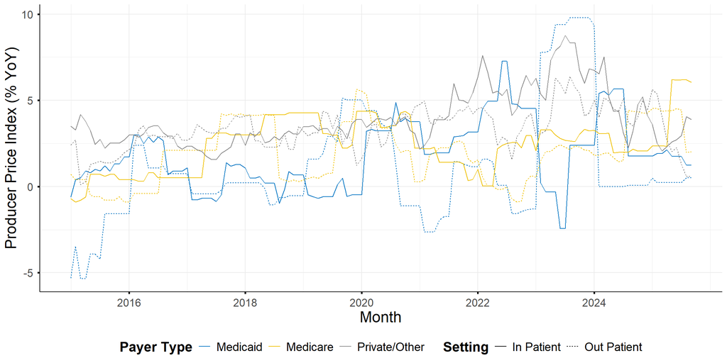

```r
temp = ppi |> as.data.table()
apply(
  X = temp[ , -1],
  MARGIN = 2,
  FUN = function(x) {
    100*(x - lag(x, 12)) / lag(x, 12)
  }
) |>
  as.data.frame() |>
  mutate(date = ppi$date) |>
  select(date, everything()) |>
  pivot_longer(cols = !date,
               names_to = 'Series',
               values_to = 'Value') |>
  na.omit() |>
  mutate(
    Setting = substr(Series, str_length(Series) - 2, str_length(Series)),
    Setting = str_replace_all(Setting, '_', ''),
    Setting = ifelse(Setting == 'in', 'In Patient', 'Out Patient'),
    `Payer Type` = str_replace_all(Series, 'ppi_|_in|_out', ''),
    `Payer Type` = ifelse(`Payer Type` == 'Other', 'Private/Other', `Payer Type`)
  ) |>
  ggplot(aes(
    x = date,
    color = `Payer Type`,
    linetype = Setting,
    y = Value
  )) +
  geom_line() +
  labs(y = 'Producer Price Index (% YoY)', x = 'Month') +
  scale_color_manual(values = ggpubr::get_palette('jco', 3)) +
  scale_x_date(breaks = seq.Date(min(ppi$date), max(ppi$date), by = "2 years"),
               date_labels = "%Y") +
  theme(legend.title = element_text(face = 'bold'))
```

### Relative Importance Weights

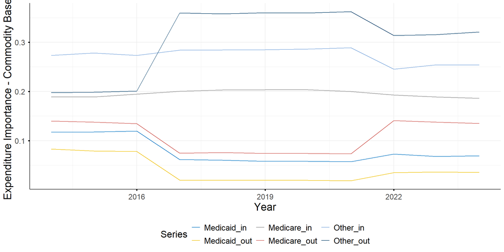

```r
if (!dir.exists(here('data/bls')))  {
  dir.create(here('data/bls'))
}

if (length(list.files(here('data/bls'))) == 0) {
  # store urls
  urls = c(
    'https://www.bls.gov/ppi/tables/wherever-provided-services-and-construction-relative-importance-2025.xlsx',
    'https://www.bls.gov/ppi/tables/wherever-provided-services-and-construction-relative-importance-2024.xlsx',
    'https://www.bls.gov/ppi/tables/wherever-provided-services-and-construction-relative-importance-2023.xlsx',
    'https://www.bls.gov/ppi/tables/wherever-provided-services-and-construction-relative-importance-2022.xlsx',
    'https://www.bls.gov/ppi/tables/wherever-provided-services-and-construction-relative-importance-2021.xlsx',
    'https://www.bls.gov/ppi/tables/wherever-provided-services-and-construction-relative-importance-2020.xlsx',
    'https://www.bls.gov/ppi/tables/wherever-provided-services-and-construction-relative-importance-2019.xlsx',
    'https://www.bls.gov/ppi/tables/wherever-provided-services-and-construction-relative-importance-2018.xlsx',
    'https://www.bls.gov/ppi/tables/wherever-provided-services-and-construction-relative-importance-2017.xlsx',
    'https://www.bls.gov/ppi/tables/wherever-provided-services-and-construction-relative-importance-2016.xlsx',
    'https://www.bls.gov/ppi/tables/wherever-provided-services-and-construction-relative-importance-2015.xlsx'
  )

  # web download
  for (i in seq_along(urls)) {
    download.file(url = urls[i],
                  destfile = here(paste0(
                    'data/bls/', 'relimport_',
                    str_replace_all(urls[i], 'https://www.bls.gov/ppi/tables/wherever-provided-services-and-construction-relative-importance-', '')
                  )),
                  mode = 'wb')

  }
}

# store file names
files = list.files(here('data/bls'), full.names = T)

# store commodity base codes
codes = c(
  '5121010111',
  # medicare inpatient
  '5121010112',
  # medicaid inpatient
  '5121010113',
  # other inpatient
  '5111040111',
  # medicare outpatient
  '5111040112',
  # medicaid outpatient
  '5111040113' # other outpatient
)

weights = list()
for (i in seq_along(files)) {
  # read the first file
  temp = read_xlsx(files[i], skip = 3) |>
    filter(`Commodity code` %in% codes)

  # check that the file has relative importance weights for each code (6)
  check = nrow(temp) == 6

  if (!check) stop('missing expenditure shares -> inspect!')

  # convert to DT
  data.table::setDT(temp)

  # drop previous rel import from 2 years ago
  temp = temp[, -3]

  # store year
  temp$year = as.integer(str_replace_all(colnames(temp)[3], 'Relative importance December ', ''))

  # rename for clarity
  colnames(temp)[3] = 'relativeImportance'

  # convert to numeric
  temp$relativeImportance = as.numeric(temp$relativeImportance)

  # normalize the relative imortance by the sum to get share of hospital expenditures
  temp$relativeImportance = temp$relativeImportance / sum(temp$relativeImportance)

  # reorder cols
  temp = temp |> select(year, everything())

  # store in list
  weights[[i]] = temp
}

# combine data frames
weights = rbindlist(weights) |>
  rename(
    code = `Commodity code`
  )

# create label data frame to merge
label_df = data.frame(
  code = codes,
  Series = c(
    'Medicare_in',
    'Medicaid_in',
    'Other_in',
    'Medicare_out',
    'Medicaid_out',
    'Other_out'
  )
)

# merge in labels
weights = left_join(weights, label_df, by = 'code') |>
  select(-Index, -code)


# plot
weights |>
  ggplot(aes(x = year, color = Series, y = relativeImportance)) +
  # geom_point() +
  geom_line() +
  labs(
    y = 'Expenditure Importance - Commodity Based',
    x = 'Year'
  ) +
  scale_color_manual(values = ggpubr::get_palette('jco', 6))
```

```r
DT::datatable(weights, caption = 'Hospital Care Expenditures (Relative Importance)', rownames = F,
              extensions = 'Buttons',
              options = list(
                dom = 'Bfrtip',
                buttons = c('copy', 'csv', 'excel')
              ))
```

| year | relativeImportance | Series |
| --- | --- | --- |
| 2014 | 0.1396982256977765 | Medicare_out |
| 2014 | 0.08295730649080181 | Medicaid_out |
| 2014 | 0.1976233742368867 | Other_out |
| 2014 | 0.1892725156706209 | Medicare_in |
| 2014 | 0.1173407926169426 | Medicaid_in |
| 2014 | 0.2731077852869714 | Other_in |
| 2015 | 0.1376952128202511 | Medicare_out |
| 2015 | 0.07882004695314893 | Medicaid_out |
| 2015 | 0.1987751352454833 | Other_out |
| 2015 | 0.1889558027967745 | Medicare_in |

[output cut: 56 more lines]

As before, we need to convert the annual relative importance weights to the monthly level.

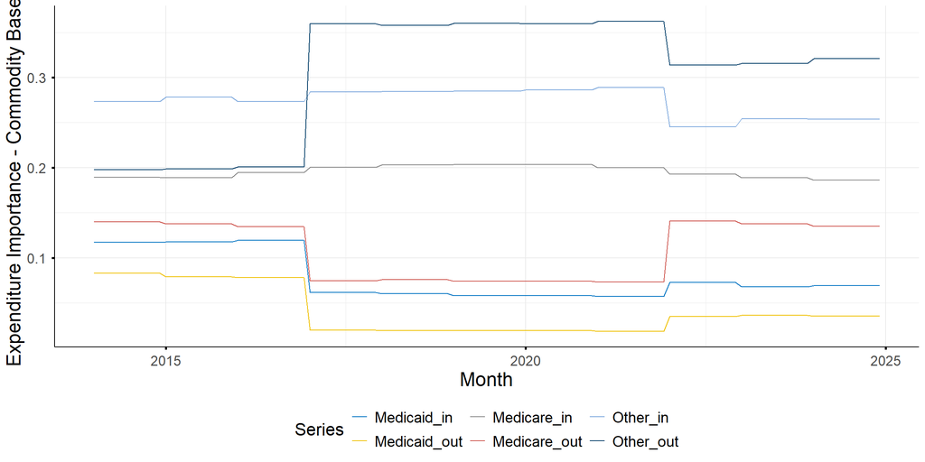

```r
ri_monthly = data.frame(
  date = seq.Date(as.Date('2014-01-01'), as.Date('2024-12-01'), by = 'month')
) |>
  mutate(
    year = year(date)
  ) |>
  left_join(weights, by = 'year') |>
  select(-year)

# plot
ri_monthly |>
  ggplot(aes(x = date, color = Series, y = relativeImportance)) +
  # geom_point() +
  geom_line() +
  labs(
    y = 'Expenditure Importance - Commodity Based',
    x = 'Month'
  ) +
  scale_color_manual(values = ggpubr::get_palette('jco', 6))
```

```r
DT::datatable(weights, caption = 'Hospital Care Expenditures (Relative Importance)', rownames = F,
              extensions = 'Buttons',
              options = list(
                dom = 'Bfrtip',
                buttons = c('copy', 'csv', 'excel')
              ))
```

| year | relativeImportance | Series |
| --- | --- | --- |
| 2014 | 0.1396982256977765 | Medicare_out |
| 2014 | 0.08295730649080181 | Medicaid_out |
| 2014 | 0.1976233742368867 | Other_out |
| 2014 | 0.1892725156706209 | Medicare_in |
| 2014 | 0.1173407926169426 | Medicaid_in |
| 2014 | 0.2731077852869714 | Other_in |
| 2015 | 0.1376952128202511 | Medicare_out |
| 2015 | 0.07882004695314893 | Medicaid_out |
| 2015 | 0.1987751352454833 | Other_out |
| 2015 | 0.1889558027967745 | Medicare_in |

[output cut: 56 more lines]

### Compute Overall Hospital Inflation

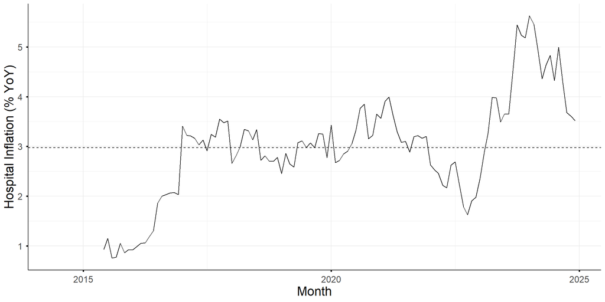

```r
# convert ppi to long format
ppi_long = ppi |>
  pivot_longer(
    cols = !date,
    names_to = 'payerType',
    values_to = 'ppi'
  ) |>
  mutate(
    payerType = str_replace_all(payerType, 'ppi_', '')
  )

# rename to payer type
ri_monthly = ri_monthly |>
  rename(
    payerType = Series
  )

# combine the data
inflation = inner_join(ri_monthly, ppi_long, by = c('date', 'payerType')) |>
  # compute overall inflation
  group_by(date) |>
  summarise(
    P_t = sum(relativeImportance*ppi)
  ) |>
  ungroup() |>
  mutate(
    pi_t = 100*(P_t - lag(P_t, 12)) / lag(P_t, 12)
  )

ggplot(inflation, aes(x = date, y = pi_t)) +
  geom_line() +
  geom_hline(yintercept = mean(inflation$pi_t, na.rm = T), linetype = 'dashed') +
  labs(
    x = 'Month',
    y = 'Hospital Inflation (% YoY)'
  )
```

```r
fwrite(inflation, here('data/analysis/commodity_based_inflation.csv'))
```

## Comparing Industry-Based and Commodity-Based Inflation

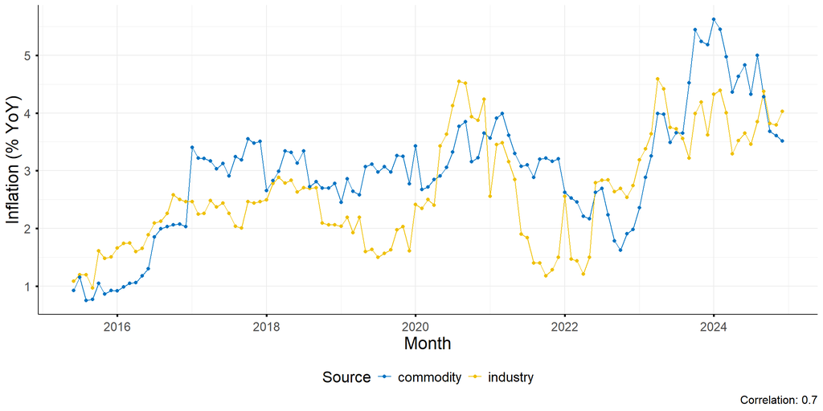

```r
ind_infl = fread(here('data/analysis/industry_based_inflation.csv')) |>
  na.omit() |>
  mutate(date = as.Date(date))

ind_infl = inner_join(ind_infl,
                      inflation,
                      by = 'date',
                      suffix = c('_industry', '_commodity')) |>
  select(date, contains('pi_')) |>
  na.omit()

ind_infl |>
  pivot_longer(
    cols = !date,
    values_to = 'Inflation',
    names_to = 'Source'
  ) |>
  mutate(
    Source = str_replace_all(Source, 'pi_t_', '')
  ) |>
  ggplot(aes(x = date, y = Inflation, color = Source)) +
  geom_line() +
  geom_point() +
  scale_color_manual(values = ggpubr::get_palette('jco', 2)) +
  labs(
    y = 'Inflation (% YoY)',
    x = 'Month',
    caption = paste0(
      'Correlation: ',
      round(cor(ind_infl$pi_t_industry, ind_infl$pi_t_commodity),2)
    )
  )
```